# K Means Clustering

```python
# Import the libraries
import numpy as np
import pandas as pd
import matplotlib.pyplot as plt
import seaborn as sns
```

```python
# Import the dataset
dataset = pd.read_csv('F:/Class/Python/Python/K-Means Cluster/Mall_Customers.csv')
```

```python
# Exploratory Data Analysis
# As this is unsupervised learning so Label (Output Column) is unknown

dataset.head(10)
```

|  | CustomerID | Genre | Age | Annual Income (k$) | Spending Score (1-100) |
| --- | --- | --- | --- | --- | --- |
| 0 | 1 | Male | 19 | 15 | 39 |
| 1 | 2 | Male | 21 | 15 | 81 |
| 2 | 3 | Female | 20 | 16 | 6 |
| 3 | 4 | Female | 23 | 16 | 77 |
| 4 | 5 | Female | 31 | 17 | 40 |
| 5 | 6 | Female | 22 | 17 | 76 |
| 6 | 7 | Female | 35 | 18 | 6 |
| 7 | 8 | Female | 23 | 18 | 94 |
| 8 | 9 | Male | 64 | 19 | 3 |
| 9 | 10 | Female | 30 | 19 | 72 |

```python
dataset.shape
```

```
(200, 5)
```

```python
dataset.info()
```

```python
dataset.isnull().sum()
```

### Feature sleection for the model

### Considering only 2 features (Annual income and Spending Score) and no Label available

```python
X = dataset.iloc[:, [3,4]].values
```

### Building the Model

In KMeans Algorithm to decide the optimum cluster number we use KMeans++ using Elbow Method to figure out K for KMeans

**Elbow Method Calculates:**

- **Distortion:** It is calculated as the average of the squared distances from the cluster centers of the respective clusters. Typically, the Euclidean distance metric is used.
- **Inertia:** It is the sum of squared distances of samples to their closest cluster center.

we have to select the value of k at the “elbow” ie the point after which the distortion/inertia start decreasing in a linear fashion.

1. Lets take max number of cluster 10 and we can decide the number of clusters by doing averaging

```python
from sklearn.cluster import KMeans
wcss=[] # Within-Cluster-Sum-of-Squares

# Code to get max no of clusters

for i in range(1,11):
    kmeans = KMeans(n_clusters= i, init='k-means++', random_state=0)
    kmeans.fit(X)
    wcss.append(kmeans.inertia_)
```

### Visualize the ELBOW method for optimal value of K

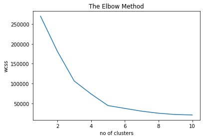

```python
plt.plot(range(1,11), wcss)
plt.title('The Elbow Method')
plt.xlabel('no of clusters')
plt.ylabel('wcss')
plt.show()
```

# There is a curve elbow at k=5

If we chose higher range it is little difficult to visualize the ELBOW, so prefer a range from 1 to 11

#### Build Model using K = 5

- For unsupervised learning we use **fit_predict()**
- For supervised learning we use **fit_tranform()**
- **y_kmeans** is the final model.

```python
kmeansmodel = KMeans(n_clusters= 5, init='k-means++', random_state=0)
y_kmeans= kmeansmodel.fit_predict(X)
```

#### Visualizing all the clusters

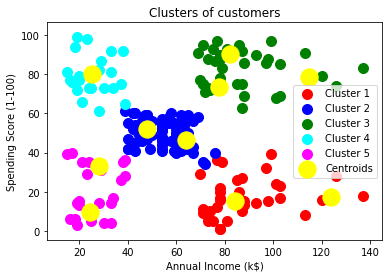

```python
plt.scatter(X[y_kmeans == 0, 0], X[y_kmeans == 0, 1], s = 100, c = 'red', label = 'Cluster 1')
plt.scatter(X[y_kmeans == 1, 0], X[y_kmeans == 1, 1], s = 100, c = 'blue', label = 'Cluster 2')
plt.scatter(X[y_kmeans == 2, 0], X[y_kmeans == 2, 1], s = 100, c = 'green', label = 'Cluster 3')
plt.scatter(X[y_kmeans == 3, 0], X[y_kmeans == 3, 1], s = 100, c = 'cyan', label = 'Cluster 4')
plt.scatter(X[y_kmeans == 4, 0], X[y_kmeans == 4, 1], s = 100, c = 'magenta', label = 'Cluster 5')
plt.scatter(kmeans.cluster_centers_[:, 0], kmeans.cluster_centers_[:, 1], s = 300, c = 'yellow', label = 'Centroids')
plt.title('Clusters of customers')
plt.xlabel('Annual Income (k$)')
plt.ylabel('Spending Score (1-100)')
plt.legend()
plt.show()
```

```python
y_kmeans
```

```
array([4, 3, 4, 3, 4, 3, 4, 3, 4, 3, 4, 3, 4, 3, 4, 3, 4, 3, 4, 3, 4, 3,
       4, 3, 4, 3, 4, 3, 4, 3, 4, 3, 4, 3, 4, 3, 4, 3, 4, 3, 4, 3, 4, 1,
       4, 3, 1, 1, 1, 1, 1, 1, 1, 1, 1, 1, 1, 1, 1, 1, 1, 1, 1, 1, 1, 1,
       1, 1, 1, 1, 1, 1, 1, 1, 1, 1, 1, 1, 1, 1, 1, 1, 1, 1, 1, 1, 1, 1,
       1, 1, 1, 1, 1, 1, 1, 1, 1, 1, 1, 1, 1, 1, 1, 1, 1, 1, 1, 1, 1, 1,
       1, 1, 1, 1, 1, 1, 1, 1, 1, 1, 1, 1, 1, 2, 0, 2, 1, 2, 0, 2, 0, 2,
       1, 2, 0, 2, 0, 2, 0, 2, 0, 2, 1, 2, 0, 2, 0, 2, 0, 2, 0, 2, 0, 2,
       0, 2, 0, 2, 0, 2, 0, 2, 0, 2, 0, 2, 0, 2, 0, 2, 0, 2, 0, 2, 0, 2,
       0, 2, 0, 2, 0, 2, 0, 2, 0, 2, 0, 2, 0, 2, 0, 2, 0, 2, 0, 2, 0, 2,
       0, 2])
```

```python
dataset["cluster_values"] = y_kmeans
```

```python
dataset.head(10)
```

|  | CustomerID | Genre | Age | Annual Income (k$) | Spending Score (1-100) | cluster_values |
| --- | --- | --- | --- | --- | --- | --- |
| 0 | 1 | Male | 19 | 15 | 39 | 4 |
| 1 | 2 | Male | 21 | 15 | 81 | 3 |
| 2 | 3 | Female | 20 | 16 | 6 | 4 |
| 3 | 4 | Female | 23 | 16 | 77 | 3 |
| 4 | 5 | Female | 31 | 17 | 40 | 4 |
| 5 | 6 | Female | 22 | 17 | 76 | 3 |
| 6 | 7 | Female | 35 | 18 | 6 | 4 |
| 7 | 8 | Female | 23 | 18 | 94 | 3 |
| 8 | 9 | Male | 64 | 19 | 3 | 4 |
| 9 | 10 | Female | 30 | 19 | 72 | 3 |

```python
# saving the dataframe
dataset.to_csv('F:/Class/Python/Python/K-Means Cluster/file1.csv')
```

### Interpretation

- Cluster 0 -> earning high but spending less
- cluster 1 -> average in terms of earning and spending
- cluster 2 -> earning high and also spending high
- cluster 3 -> earning less but spending more
- Cluster 4 -> Earning less , spending less
- Cluster 2 has earning high and also spending high they are easy to convert